# Homework-2024.10.21

By SA24204148

2024-12-09

## Question 7.8

Efron and Tibshirani discuss the scor (bootstrap) test score data on 88 students who took examinations in five subjects. The first two tests (mechanics, vectors) were closed book and the last three tests (algebra, analysis, statistics) were open book. Each row of the data frame is a set of scores $(x_{i1},\cdots,x_{i5})$ for the $i^{th}$ student.

The five-dimensional scores data have a $5 \times 5$ covariance matrix $\Sigma$, with positive eigenvalues $\lambda_1>\cdots>\lambda_5$. In principal components analysis,

$$\theta=\frac{\lambda_1}{\Sigma\lambda_i}$$
measures the proportion of variance explained by the first principal component. Let $\hat{\lambda}_1>\cdots>\hat{\lambda}_5$ be the eigenvalues of $\hat{\Sigma}$, where $\hat{\Sigma}$ is the MLE of ${\Sigma}$. Compute the sample estimate

$$\theta=\frac{\hat{\lambda}_1}{\Sigma\hat{\lambda}_i}$$
of $\theta$. Obtain the jackknife estimates of bias and standard error of $\hat{\theta}$.

## Answer

First, let us briefly take a look at this data.

```r
# The dataset contains the test scores in five subjects
data(scor)

head(scor)
```

```
##   mec vec alg ana sta
## 1  77  82  67  67  81
## 2  63  78  80  70  81
## 3  75  73  71  66  81
## 4  55  72  63  70  68
## 5  63  63  65  70  63
## 6  53  61  72  64  73
```

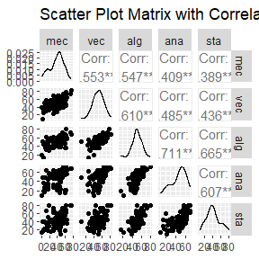

```r
# Panel display of scatter plots with correlations
ggpairs(scor, title = "Scatter Plot Matrix with Correlations")
```

The matrix shows strong to moderate positive relationships between most subjects, particularly among algebra, analysis, and statistics. However, mechanics shows weaker associations with other subjects, suggesting that it may require different skills or understanding compared to the others.

Next, try to obtain the jackknife estimates of bias and standard error of $\hat{\theta}$

```r
# Function to compute the proportion of variance explained by the first principal component
pve_first_pc <- function(data, indices, loc = NULL) {
  d <- data[indices, ]
  cov_matrix <- cov(d)
  eigenvalues <- eigen(cov_matrix)$values
  theta_hat <- eigenvalues[1] / sum(eigenvalues)
  return(theta_hat)
}

# Number of observations
n <- nrow(scor)

# Placeholder for jackknife estimates of the correlation
jackknife_theta <- numeric(n)

# Calculate correlation leaving one observation out at a time
for (i in 1:n) {
  # Leave the i-th observation out and calculate the correlation
  jackknife_theta[i] <- pve_first_pc(scor,(seq(n)[-i]))
}

# Jackknife estimate of the correlation (mean of leave-one-out correlations)
jackknife_mean <- mean(jackknife_theta)

# original theta_hat

theta_full <- pve_first_pc(scor,seq(n))

# Jackknife bias estimate
bias_jack <- (n - 1) * (jackknife_mean - theta_full)

# Jackknife standard error estimate
se_jack <- sqrt(((n - 1) / n) * sum((jackknife_theta - jackknife_mean)^2))

# Output the results
cat("Original Theta (Full Data):", theta_full, "\n")
```

```
## Original Theta (Full Data): 0.619115
```

```r
cat("Jackknife Estimate:", jackknife_mean, "\n")
```

```
## Jackknife Estimate: 0.6191273
```

```r
cat("Jackknife Bias Estimate:", bias_jack, "\n")
```

```
## Jackknife Bias Estimate: 0.001069139
```

```r
cat("Jackknife Standard Error Estimate:", se_jack, "\n")
```

```
## Jackknife Standard Error Estimate: 0.04955231
```

Compare it with the Bootstrap estimates:

```r
# Bootstrap to estimate bias and standard error for proportion of variance explained
set.seed(123)
boot_pve_results <- boot(data = scor, statistic = pve_first_pc, R = 1000, loc = NULL)

# Standard error and bias
boot_pve_bias <- mean(boot_pve_results$t) - boot_pve_results$t0
boot_pve_se <- sd(boot_pve_results$t)

result <- rbind(c(boot_pve_bias,boot_pve_se),c(bias_jack,se_jack))

colnames(result) <- c("bias", "se")
rownames(result) <- c("bootstrap", "jackknife")

round(result,4)
```

```
##             bias     se
## bootstrap 0.0022 0.0474
## jackknife 0.0011 0.0496
```

Both methods show a small bias, with the Bootstrap method estimating a slightly higher bias than the Jackknife method. The bootstrap method yields a slightly smaller standard error (0.0474) compared to the jackknife method (0.0496). The difference in SE is small, but the jackknife method shows a bit more variability in the estimate of the correlation.

In this case, the bias is quite small in both methods, suggesting that the estimate is relatively unbiased.

## Question 7.10

In Example 7.18, leave-one-out (n-fold) cross validation was used to select the best fitting model. Repeat the analysis replacing the Log-Log model with a cubic polynomial model. Which of the four models is selected by the cross validation procedure? Which model is selected according to maximum adjusted $R^2$?

## Answer

The ironslag data has 53 measurements of iron content by two methods, chemical and magnetic. A scatterplot of the data in Figure below suggests that the chemical and magnetic variables are positively correlated, but the relation may not be linear.

The proposed models for predicting magnetic measurement (Y) from chemical measurement (X) are:

- Linear: $Y=\beta_0+\beta_1X+\epsilon$
- Quadratic: $Y=\beta_0+\beta_1X+\beta_2X^2+\epsilon$
- Exponential: $log(Y)=log(\beta_0)+\beta_1X+\epsilon$
- Cubic: $Y=\beta_0+\beta_1X+\beta_2X^2+\beta_3X^3+\epsilon$

Once the model is estimated, we want to assess the fit. Cross validation can be used to estimate the prediction errors:

- For $k = 1,\cdots,n$, let observation $(x_k, y_k)$ be the test point and use the remaining observations to fit the model
- Compute the predicted response $_k $ for the test point
- Compute the prediction error $e_k = y_k − \hat{y}_k$
- Estimate the mean of the squared prediction errors $\hat{\sigma}^2=\frac{1}{n}\sum e^2_k$

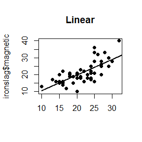

```r
data(ironslag)
# par(mfrow=c(2,2), mar = c(5, 4, 4, 2) + 0.1)

a <- seq(10, 40, .1) #sequence for plotting fits
L1 <- lm(magnetic ~ chemical, data = ironslag)
plot(ironslag$chemical, ironslag$magnetic, main = "Linear", pch = 16 ,xlab = "")
yhat1 <- L1$coef[1] + L1$coef[2] * a
lines(a, yhat1, lwd=2)
```

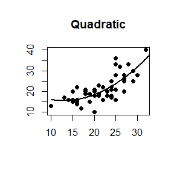

```r
L2 <- lm(magnetic ~ chemical + I(chemical^2), data = ironslag)
plot(ironslag$chemical, ironslag$magnetic, main="Quadratic", pch=16, xlab = "", ylab = "")
yhat2 <- L2$coef[1] + L2$coef[2] * a + L2$coef[3] * a^2
lines(a, yhat2, lwd=2)
```

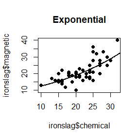

```r
L3 <- lm(log(magnetic) ~ chemical, data = ironslag)
plot(ironslag$chemical, ironslag$magnetic, main="Exponential", pch=16,)
logyhat3 <- L3$coef[1] + L3$coef[2] * a
yhat3 <- exp(logyhat3)
lines(a, yhat3, lwd=2)
```

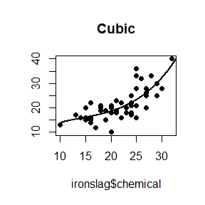

```r
L4 <- lm(magnetic ~ chemical + I(chemical^2) + I(chemical^3), data = ironslag)
plot(ironslag$chemical, ironslag$magnetic, main="Cubic", pch=16, ylab = "")
yhat4 <- L4$coef[1] + L4$coef[2] * a + L4$coef[3] * a^2 + L4$coef[4] * a^3
lines(a, yhat4, lwd=2)
```

```r
n <- length(ironslag$magnetic) #in DAAG ironslag
e1 <- e2 <- e3 <- e4 <- numeric(n)

# for n-fold cross validation
# fit models on leave-one-out samples
for (k in 1:n) {
  y <- ironslag$magnetic[-k]
  x <- ironslag$chemical[-k]

  J1 <- lm(y ~ x)
  yhat1 <- J1$coef[1] + J1$coef[2] * ironslag$chemical[k]
  e1[k] <- ironslag$magnetic[k] - yhat1

  J2 <- lm(y ~ x + I(x^2))
  yhat2 <- J2$coef[1] + J2$coef[2] * ironslag$chemical[k] + J2$coef[3] * ironslag$chemical[k]^2
  e2[k] <- ironslag$magnetic[k] - yhat2

  J3 <- lm(log(y) ~ x)
  logyhat3 <- J3$coef[1] + J3$coef[2] * ironslag$chemical[k]
  yhat3 <- exp(logyhat3)
  e3[k] <- ironslag$magnetic[k] - yhat3

  J4 <- lm(y ~ x + I(x^2) + I(x^3))
  yhat4 <- J4$coef[1] + J4$coef[2] * ironslag$chemical[k] + J4$coef[3] * ironslag$chemical[k]^2 + J4$coef[4] * ironslag$chemical[k]^3
  e4[k] <- ironslag$magnetic[k] - yhat4
}

c(mean(e1^2), mean(e2^2), mean(e3^2), mean(e4^2))
```

```
## [1] 19.55644 17.85248 18.44188 18.17756
```

According to the prediction error criterion, Model 2, the quadratic model would be the best fit for the data.

```r
summary(L1)$adj.r.squared
```

```
## [1] 0.5281545
```

```r
summary(L2)$adj.r.squared
```

```
## [1] 0.5768151
```

```r
summary(L3)$adj.r.squared
```

```
## [1] 0.5280556
```

```r
summary(L4)$adj.r.squared
```

```
## [1] 0.5740396
```

According to maximum adjusted $R^2$, Model 2, the quadratic model would also be the best fit for the data.

## Question 8.1

Implement the two-sample Cramer-von Mises test for equal distributions as a permutation test. Apply the test to the data in Examples 8.1 and 8.2.

## Answer

In the data from Examples 8.1, Weights in grams are recorded, for six groupsof newly hatched chicks fed different supplements. There are six types of feed supplements. The plot below suggests that soybean and linseed groups may be similar.

```r
data("chickwts")
head(chickwts)
```

```
##   weight      feed
## 1    179 horsebean
## 2    160 horsebean
## 3    136 horsebean
## 4    227 horsebean
## 5    217 horsebean
## 6    168 horsebean
```

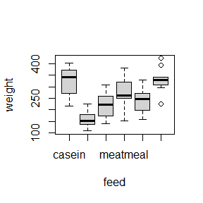

```r
boxplot(formula(chickwts),data = chickwts)
```

The distribution of weights for these two groups are compared below.

```r
x <- sort(as.vector(chickwts[chickwts$feed == "soybean",1]))
y <- sort(as.vector(chickwts[chickwts$feed == "linseed",1]))

# Define the Cramer-von Mises statistic based on the provided formula
cvm_statistic <- function(x, y) {
  # Sample sizes
  n <- length(x)
  m <- length(y)

  # Combine x and y into a single vector
  combined <- c(x, y)

  # Sort combined data
  combined_sorted <- sort(combined)

  # ECDF for x and y
  Fn <- ecdf(x)  # ECDF for sample x
  Gm <- ecdf(y)  # ECDF for sample y

  # Cramer-von Mises test statistic as per the given formula
  W2 <- (n * m) / (n + m)^2 * (
    sum((Fn(x) - Gm(x))^2) +  # Summation for x_i terms
    sum((Fn(y) - Gm(y))^2)    # Summation for y_j terms
  )

  return(W2)
}

# Perform the permutation test
permutation_test <- function(x, y, n_perm = 1000) {
  # Observed Cramer-von Mises statistic
  observed_stat <- cvm_statistic(x, y)

  # Combine x and y
  combined <- c(x, y)
  n <- length(combined)

  # Initialize a vector to store permutation statistics
  perm_stats <- numeric(n_perm)

  # Run permutation
  for (i in 1:n_perm) {
    # Permute the combined data
    permuted <- sample(combined, size = n, replace = FALSE)

    # Split permuted data into two groups
    perm_x <- permuted[1:length(x)]
    perm_y <- permuted[(length(x) + 1):n]

    # Calculate the Cramer-von Mises statistic for the permuted samples
    perm_stats[i] <- cvm_statistic(perm_x, perm_y)
  }

  # Calculate p-value
  p_value <- mean(perm_stats >= observed_stat)

  # Return observed statistic and p-value
  return(list(observed_stat = observed_stat, p_value = p_value, perm_stats = perm_stats))
}

# Example usage
set.seed(123)

# Perform the permutation test
result <- permutation_test(x, y, n_perm = 1000)

# Display the results
result$observed_stat  # Observed Cramer-von Mises statistic
```

```
## [1] 0.1515216
```

```r
result$p_value        # Permutation test p-value
```

```
## [1] 0.422
```

The approximate ASL 0.422 does not support the alternative hypothesis that distributions differ.

A histogram of the replicates of $W^2$ is displayed below.

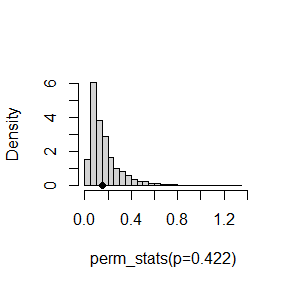

```r
hist(result$perm_stats, main = "", xlab = "perm_stats(p=0.422)",freq = FALSE, breaks = "scott")
points(result$observed_stat, 0, cex = 1, pch = 16) #observed W2
```

## Question 8.2

Implement the bivariate Spearman rank correlation test for independence as a permutation test. The Spearman rank correlation test statistic can be obtained from function cor with method = “spearman”. Compare the achieved significance level of the permutation test with the p-value reported by cor.test on the same samples.

## Answer

First, generate two random samples:

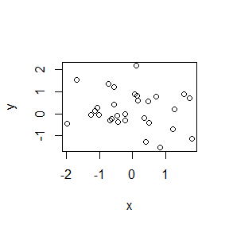

```r
set.seed(123)  # For reproducibility

# Generate two random samples
x <- rnorm(30)
y <- rnorm(30)
plot(x,y)
```

```r
# 1. Compute the observed Spearman correlation
observed_corr <- cor(x, y, method = "spearman")

# 2. Perform the permutation test
perm_test_spearman <- function(x, y, num_permutations = 1000) {
  # Initialize a vector to store permuted correlations
  permuted_corrs <- numeric(num_permutations)
  combined <- c(x, y)

  n = length(x)
  m = length(y)

  # Loop over the number of permutations
  for (i in 1:num_permutations) {

    permuted_index <- sample(1:(n+m), n, FALSE)

    # Calculate the Spearman correlation with shuffled data
    permuted_corrs[i] <- cor(combined[permuted_index], combined[-permuted_index], method = "spearman")
  }

  # Return the permuted correlations
  return(permuted_corrs)
}

# Number of permutations
num_permutations <- 1000

# Run the permutation test
permuted_corrs <- perm_test_spearman(x, y, num_permutations)

# 3. Calculate the permutation p-value
p_value_perm <- mean(abs(permuted_corrs) >= abs(observed_corr))

# 4. Compare with the p-value from cor.test
spearman_test <- cor.test(x, y, method = "spearman")

# Results
cat("Observed Spearman correlation:", observed_corr, "\n")
```

```
## Observed Spearman correlation: -0.1190211
```

```r
cat("Permutation p-value:", p_value_perm, "\n")
```

```
## Permutation p-value: 0.515
```

```r
cat("Spearman test p-value:", spearman_test$p.value, "\n")
```

```
## Spearman test p-value: 0.5294988
```

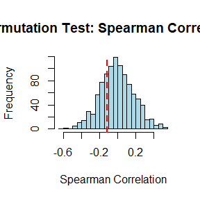

```r
# Plot histogram of permuted correlations
hist(permuted_corrs, main = "Permutation Test: Spearman Correlations",
     xlab = "Spearman Correlation", col = "lightblue", breaks = 30)
abline(v = observed_corr, col = "red", lwd = 2, lty = 2)  # Mark observed correlation
```

Both the permutation test and the standard Spearman test (via cor.test()) give similar p-values, suggesting there is no strong evidence to reject the null hypothesis of independence between the two variables. The result shows that the observed Spearman correlation is likely due to random chance, and there is no significant monotonic relationship between the two samples.

This indicates the two samples are likely independent.